# Graduate Program Acceptance Analysis-Dalton Hall

# Introduction:

We will be looking at and analyzing data that shows the grade point average, GRE score, rank of school and acceptance of 400 individuals. The data that we are examining is assigned the name “df” from here on out unless otherwise specified.

# Making a Summary and Cleaning the Data

We first will need to arrange the data into a more user friendly format, then we look at a summary of the data.

```r
#clean data
df$admit <- as.logical(df$admit)

df$rank <- factor(df$rank)

summary(df)
```

```
##    admit              gre             gpa        rank
##  Mode :logical   Min.   :220.0   Min.   :2.260   1: 61
##  FALSE:273       1st Qu.:520.0   1st Qu.:3.130   2:151
##  TRUE :127       Median :580.0   Median :3.395   3:121
##                  Mean   :587.7   Mean   :3.390   4: 67
##                  3rd Qu.:660.0   3rd Qu.:3.670
##                  Max.   :800.0   Max.   :4.000
```

The summary tells us that a large portion of the sample size comes from rank 2 and 3 undergraduate schools. It also tells us that 127 out of the 400 student were actually accepted into a graduate program. Furthermore, the median gre and gpa values are 580.0 and 3.395 respectively.

# Testing some Models

A model is used to predict hypothetical outcomes of a situation using real data as a reference point.

The first model tested tries to predict admittance based on gre, rank, and gpa, as well as the interaction between gpa vs gre and rank.

```r
mod1 <- glm(data=df, formula = admit~ gre + rank * gpa)

stepAIC(mod1)
```

```
## Start:  AIC=500.04
## admit ~ gre + rank * gpa
##
##            Df Deviance    AIC
## - rank:gpa  3   77.975 495.12
## <none>          77.764 500.04
## - gre       1   78.611 502.37
##
## Step:  AIC=495.12
## admit ~ gre + rank + gpa
##
##        Df Deviance    AIC
## <none>      77.975 495.12
## - gre   1   78.797 497.32
## - gpa   1   79.145 499.08
## - rank  3   82.557 511.96
```

```
##
## Call:  glm(formula = admit ~ gre + rank + gpa, data = df)
##
## Coefficients:
## (Intercept)          gre        rank2        rank3        rank4          gpa
##  -0.2589102    0.0004296   -0.1623653   -0.2905705   -0.3230264    0.1555350
##
## Degrees of Freedom: 399 Total (i.e. Null);  394 Residual
## Null Deviance:       86.68
## Residual Deviance: 77.98     AIC: 495.1
```

Among all these numbers we are focusing on the final AIC value on the bottom right. The lower this value, the more precise our model should be.

The second model tries to predict admittance based on rank, gpa, and gre. By setting the family to binomial, we allow for a more true depiction of our dependent variable “admit”, since admission is only true or false.

```r
mod2 <- glm(data= df, formula = admit~ rank + gpa+ gre, family = "binomial")


stepAIC(mod2)
```

```
## Start:  AIC=470.52
## admit ~ rank + gpa + gre
##
##        Df Deviance    AIC
## <none>      458.52 470.52
## - gre   1   462.88 472.88
## - gpa   1   464.53 474.53
## - rank  3   480.34 486.34
```

```
##
## Call:  glm(formula = admit ~ rank + gpa + gre, family = "binomial",
##     data = df)
##
## Coefficients:
## (Intercept)        rank2        rank3        rank4          gpa          gre
##   -3.989979    -0.675443    -1.340204    -1.551464     0.804038     0.002264
##
## Degrees of Freedom: 399 Total (i.e. Null);  394 Residual
## Null Deviance:       500
## Residual Deviance: 458.5     AIC: 470.5
```

Comparing the two values, the second model has a lower AIC, thus we use the second model from here on out.

As an extra bit of info, we can look the mean squared residual of our model.

```r
mean(mod2$residuals^2)
```

```
## [1] 5.419835
```

This tells us how well our data points agree with our model. This concept will become more clear when we look as graphs of our predictions.

Now, we add predited values to our data based upon the model we created.

```r
df_pred <- add_predictions(df,mod2, type = "response")
```

# Showing various plots of the predicted data

Our first plot example pits gpa vs our model’s predictions

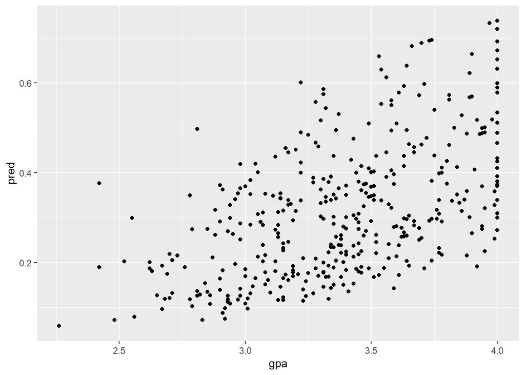

```r
ggplot(df_pred, aes(x=gpa, y=pred)) + geom_point()
```

It appears that acceptance should go up with gpa, but lets include rank as well.

This next chart will show gpa against our predictions, but with the rank of each school color coded as well.

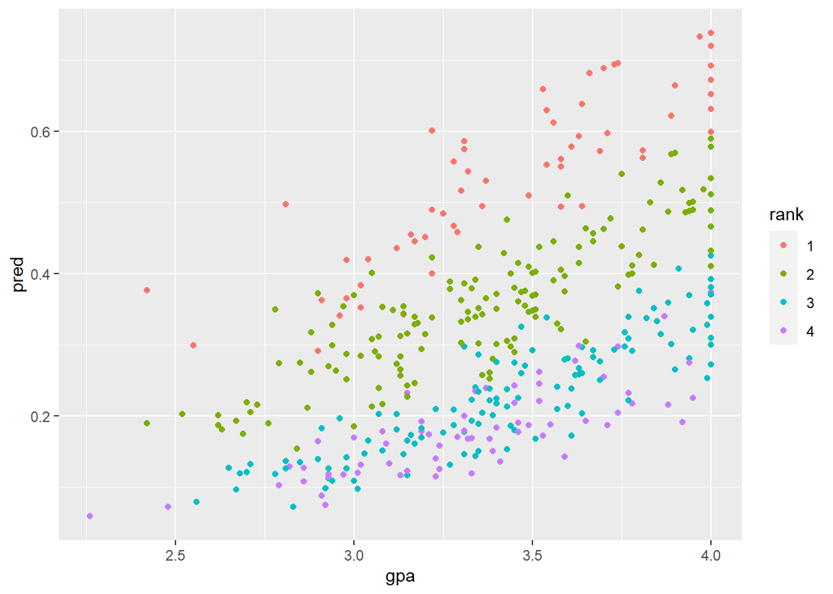

```r
ggplot(df_pred, aes(x=gpa, y=pred, color=rank)) + geom_point()
```

It looks like the higher rank undergraduate school you come from, the higher your expected acceptance.

Also within each rank, the higher gpa increases expected acceptance.

# Now lets look at gre plotted against our predictions:

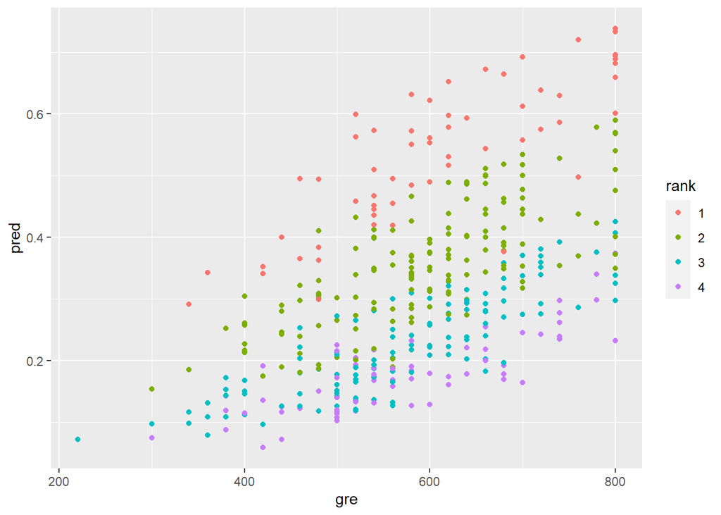

```r
ggplot(df_pred, aes(x=gre, y=pred, color=rank)) + geom_point()
```

We get very similar results, with higher gre increasing likelihood of graduate school acceptance.

Note that higher ranked schools still having the advantage in each category.

# Now lets compare predictions with reality:

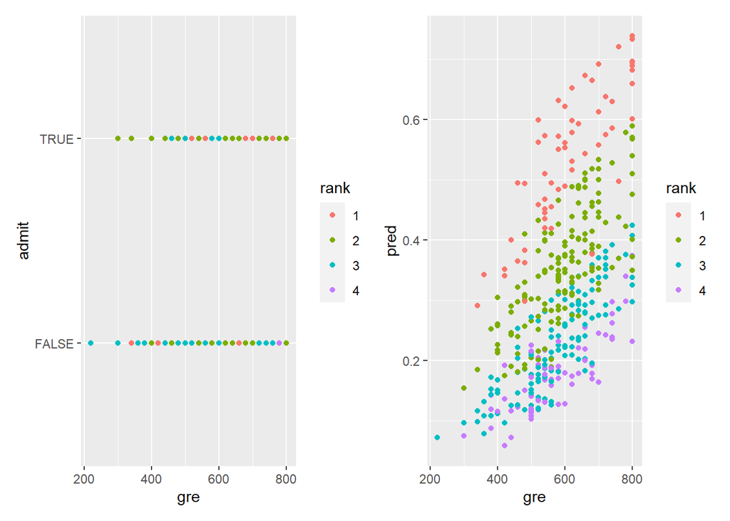

```r
p1 <- ggplot(df, aes(x= gre, y= admit, color=rank)) +geom_point()
p2 <- ggplot(df_pred, aes(x=gre, y=pred, color=rank)) + geom_point()
p1 + p2
```

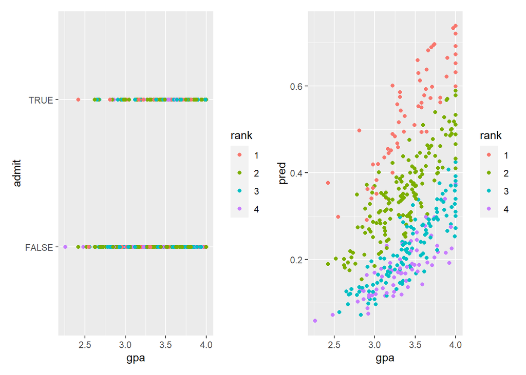

```r
p3 <- ggplot(df_pred, aes(x=gpa, y=pred, color=rank)) + geom_point()
p4 <- ggplot(df, aes(x= gpa, y= admit, color=rank)) +geom_point()
p4 + p3
```

On the left we have the actual acceptance data, on the right we have predicted acceptance data based on either gre for the top section, or gpa for the lower section. Since acceptance is true or false we only get two groups on the left graph. The model predicts acceptance on a scale of increasing likelihood, thus isnt as cut and dry as the real data.

# Conclusion from the comparison:

These show us that while it is rare, individuals with low gre and/or gpa do in reality get admitted to grad school.

It also shows that regardless of gpa or gre, coming from a higher ranking school gives an advantage.

gre and gpa do play a roll however in making the individual more appealing within their ranked school.